# 文体的特徴にもとづく青空文庫の作品の著者分類

2022-07-21

paithiov909

- はじめに
- データの準備
  - 前処理
  - 出現頻度の集計
  - 共起ネットワーク
  - バルーンプロット
- 対応分析
- TF-IDF
- ロジスティック回帰
- セッション情報

## はじめに

この記事では、青空文庫にある作品について、「助詞-記号」「助動詞-記号」「接続詞-記号」のパターンのマイニングをします。その後に、いくつかのパターンの出現比率を特徴量として、芥川龍之介（芥川竜之介）と太宰治の2例について、ロジスティック回帰で著者分類を試します。

## データの準備

### 前処理

ここでは、青空文庫にある以下の10人の作家の文章のうち「新字新仮名」で書かれているもののなかから一部を収集したデータセットを使います。

- 芥川龍之介（芥川竜之介）
- 太宰治
- 泉鏡花
- 菊池寛
- 森鴎外
- 夏目漱石
- 岡本綺堂
- 佐々木味津三
- 島崎藤村
- 海野十三

作品ごとの分量にかなりばらつきがあるので、このなかから文字数が5,000字未満のものを100篇だけランダムに抽出して分析します。

```r
tmp <- tempfile(fileext = ".zip")
download.file("https://github.com/paithiov909/shiryo/raw/main/data/aozora.csv.zip", tmp)

df <- readr::read_csv(tmp, col_types = "cccf") |>
  dplyr::mutate(author = as.factor(author)) |>
  dplyr::filter(nchar(text) < 5000) |>
  dplyr::slice_sample(n = 100L)
```

作家ごとの大まかな文章量は次のようになっています。作家によって作品数にやや偏りがあります。

```r
df |>
  dplyr::mutate(nchar = nchar(text)) |>
  dplyr::group_by(author) |>
  dplyr::summarise(
    nchar_mean = mean(nchar),
    nchar_median = median(nchar),
    nchar_min = min(nchar),
    nchar_max = max(nchar),
    n = dplyr::n()
  ) |>
  dplyr::mutate(across(where(is.numeric), trunc))
```

```
#> # A tibble: 8 × 6
#>   author     nchar_mean nchar_median nchar_min nchar_max     n
#>   <fct>           <dbl>        <dbl>     <dbl>     <dbl> <dbl>
#> 1 芥川竜之介       2425         2373       435      4811    20
#> 2 太宰治           1572          982       130      4209    31
#> 3 岡本綺堂         2904         3064       558      4842    16
#> 4 泉鏡花           3988         4309      2618      4715     4
#> 5 森鴎外           2324         2117      1125      4574     5
#> 6 夏目漱石         2393         1983       768      4199    16
#> 7 島崎藤村         1192         1192      1192      1192     1
#> 8 海野十三         3218         3158      1363      4724     7
```

`audubon::strj_normalize`で文字列を正規化したうえで、gibasaで分かち書きにします。

```r
df <- df |>
  dplyr::mutate(doc_id = title, text = audubon::strj_normalize(text)) |>
  dplyr::select(doc_id, text, author) |>
  gibasa::tokenize(split = TRUE) |>
  gibasa::prettify(col_select = "POS1")

summary(df)
```

```
#>                             doc_id              author       sentence_id
#>  世界怪談名作集                : 17190   岡本綺堂  :41415   Min.   :  1.00
#>  海のほとり                    :  3087   芥川竜之介:31277   1st Qu.: 14.00
#>  平造とお鶴                    :  3078   太宰治    :30646   Median : 32.00
#>  おばけずきのいわれ少々と処女作:  3068   夏目漱石  :25221   Mean   : 39.14
#>  海の使者                      :  3004   海野十三  :13861   3rd Qu.: 56.00
#>  のろのろ砲弾の驚異            :  2984   泉鏡花    :10767   Max.   :198.00
#>  (Other)                       :128888   (Other)   : 8112
#>     token_id         token               POS1
#>  Min.   :  1.00   Length:161299      Length:161299
#>  1st Qu.:  7.00   Class :character   Class :character
#>  Median : 14.00   Mode  :character   Mode  :character
#>  Mean   : 19.35
#>  3rd Qu.: 26.00
#>  Max.   :184.00
#>
```

### 出現頻度の集計

30回以上出現するパターンをグラフにします。「た-。」という文末の表現や「は-、」という主題を表したりする表現が多いようです。

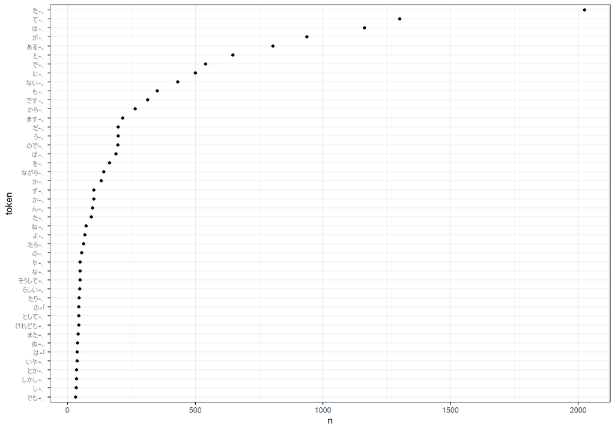

```r
require(ggplot2)
df |>
  dplyr::group_by(doc_id) |>
  dplyr::mutate(
    POS1 = paste(POS1, dplyr::lead(POS1), sep = "-"),
    token = paste(token, dplyr::lead(token), sep = "-")
  ) |>
  dplyr::ungroup() |>
  dplyr::filter(POS1 %in% c("助詞-記号", "助動詞-記号", "接続詞-記号")) |>
  dplyr::count(token) |>
  dplyr::filter(n >= 30) |>
  ggpubr::ggdotchart(
    x = "token", y = "n",
    rotate = TRUE, sorting = "descending",
    ggtheme = theme_bw()
  )
```

### 共起ネットワーク

共起関係についてネットワーク図を描いてみます。一部の語は「、」と「。」のどちらとも共起するようです。

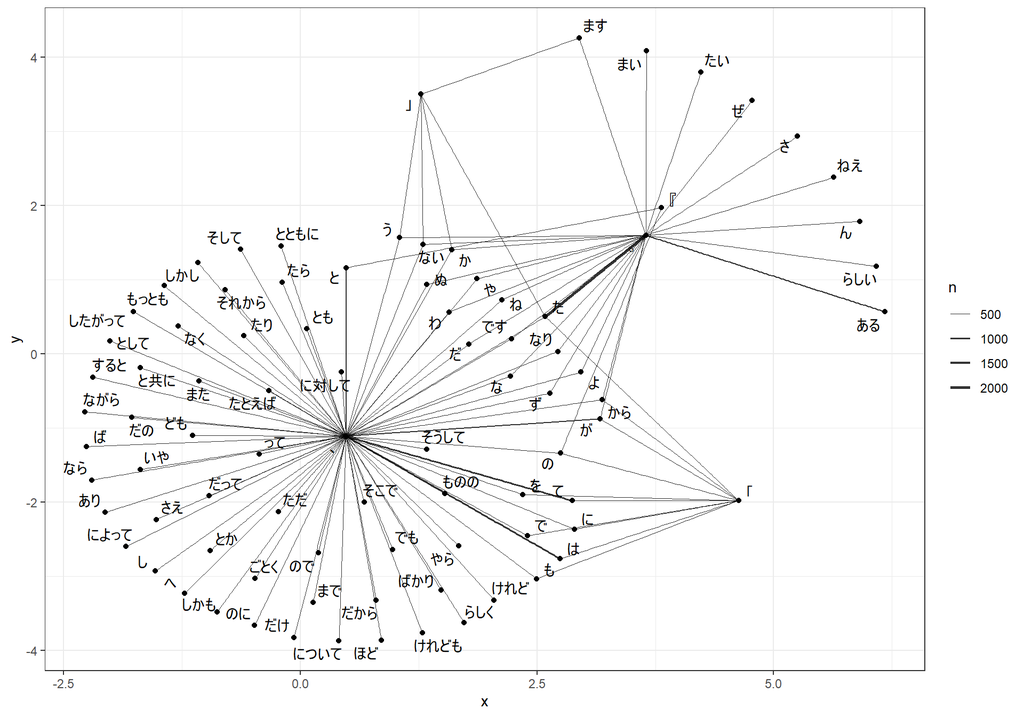

```r
df |>
  dplyr::group_by(doc_id) |>
  dplyr::mutate(
    POS1 = paste(POS1, dplyr::lead(POS1), sep = "-"),
    from = token, to = dplyr::lead(token)
  ) |>
  dplyr::ungroup() |>
  dplyr::filter(POS1 %in% c("助詞-記号", "助動詞-記号", "接続詞-記号")) |>
  dplyr::count(from, to) |>
  dplyr::filter(n > 5) |>
  tidygraph::as_tbl_graph() |>
  ggraph::ggraph(layout = "kk") +
  ggraph::geom_edge_link(aes(width = n), alpha = .8) +
  ggraph::scale_edge_width(range = c(.1, 1)) +
  ggraph::geom_node_point() +
  ggraph::geom_node_text(aes(label = name), repel = TRUE) +
  theme_bw()
```

### バルーンプロット

作家ごとに頻度を比較できるようにプロットしてみます（もっとも、青空文庫には極端に短い作品がたまにあったりするので、単純な頻度を比較するのはあまり適切でないかもしれません）。

なお、たとえば「神は言っている、ここで死ぬ定めではないと。」のような倒置で文末にくる「と-。」という表現や、「も-。」「で-、」といった表現などはやや特殊なようで、後でバイプロットにしたとき図が偏るため、ここでは集計から省いておきます。

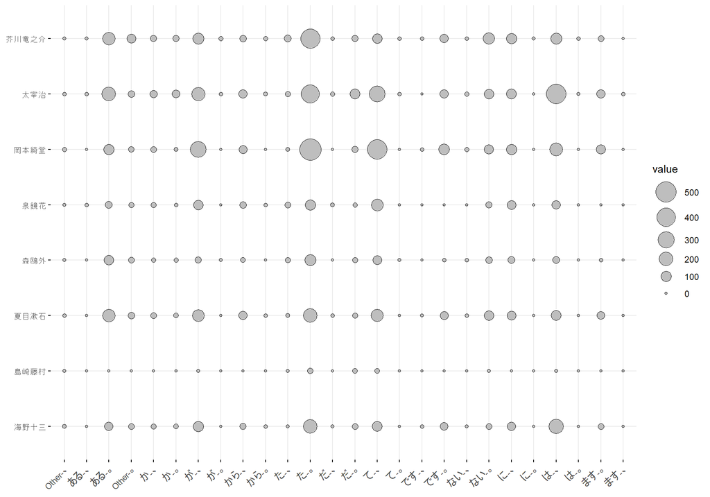

```r
dfm <- df |>
  dplyr::group_by(doc_id) |>
  dplyr::mutate(
    POS1 = paste(POS1, dplyr::lead(POS1), sep = "-"),
    from = token, to = dplyr::lead(token)
  ) |>
  dplyr::ungroup() |>
  dplyr::filter(
    POS1 %in% c("助詞-記号", "助動詞-記号", "接続詞-記号"),
    !from %in% c("と", "も", "で"),
    to %in% c("、", "。")
  ) |>
  dplyr::count(author, from, to) |>
  dplyr::mutate(
    author = forcats::fct_drop(author),
    from = forcats::fct_lump(from, n = 12, w = n),
    term = paste(from, to, sep = "-")
  ) |>
  tidytext::cast_dfm(author, term, n)

dfm |>
  quanteda::convert(to = "data.frame") |>
  tibble::column_to_rownames("doc_id") |>
  ggpubr::ggballoonplot()
```

## 対応分析

対応分析してバイプロットを描いてみます。

```r
mdl <- dfm |>
  quanteda.textmodels::textmodel_ca()

require(ca)
```

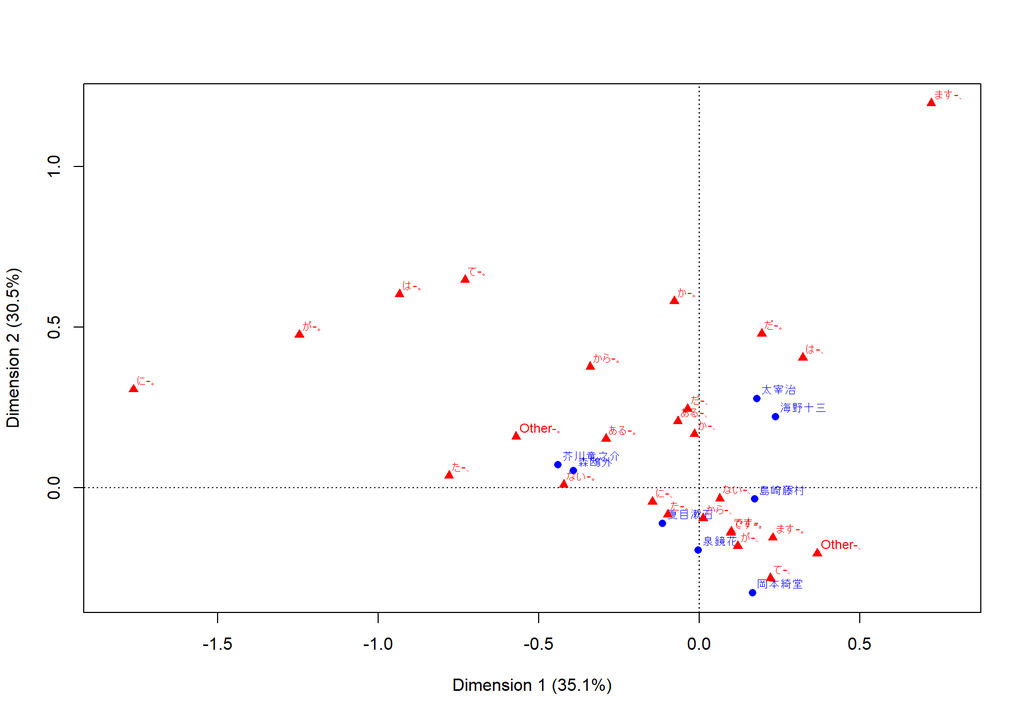

```r
plot(mdl)
```

## TF-IDF

「と-。」と「も-。」「で-、」のTF-IDFなどを確認します。ここでのTF-IDFなどは、すべてのトークンについてのものではなく、あくまでマイニングしているパターンのなかでの値です。

「と-。」と「も-。」に関しては、そもそもほとんど使われない表現のようです。

```r
df |>
  dplyr::group_by(doc_id) |>
  dplyr::mutate(
    POS1 = paste(POS1, dplyr::lead(POS1), sep = "-"),
    from = token, to = dplyr::lead(token)
  ) |>
  dplyr::ungroup() |>
  dplyr::filter(POS1 %in% c("助詞-記号", "助動詞-記号", "接続詞-記号")) |>
  dplyr::count(author, from, to) |>
  dplyr::mutate(term = paste(from, to, sep = "-")) |>
  tidytext::bind_tf_idf(term, author, n) |>
  dplyr::filter(term == "と-。") |>
  dplyr::select(author, term, n, tf, idf, tf_idf)
```

```
#> # A tibble: 2 × 6
#>   author     term      n       tf   idf   tf_idf
#>   <fct>      <chr> <int>    <dbl> <dbl>    <dbl>
#> 1 芥川竜之介 と-。     1 0.000440  1.39 0.000610
#> 2 太宰治     と-。     1 0.000314  1.39 0.000435
```

```r
df |>
  dplyr::group_by(doc_id) |>
  dplyr::mutate(
    POS1 = paste(POS1, dplyr::lead(POS1), sep = "-"),
    from = token, to = dplyr::lead(token)
  ) |>
  dplyr::ungroup() |>
  dplyr::filter(POS1 %in% c("助詞-記号", "助動詞-記号", "接続詞-記号")) |>
  dplyr::count(author, from, to) |>
  dplyr::mutate(term = paste(from, to, sep = "-")) |>
  tidytext::bind_tf_idf(term, author, n) |>
  dplyr::filter(term == "も-。") |>
  dplyr::select(author, term, n, tf, idf, tf_idf)
```

```
#> # A tibble: 1 × 6
#>   author term      n       tf   idf   tf_idf
#>   <fct>  <chr> <int>    <dbl> <dbl>    <dbl>
#> 1 太宰治 も-。     1 0.000314  2.08 0.000652
```

一方で、「で-、」という表現はどの作家も使ってはいるものの、TFを見るとすこし差があるように見えます。

```r
df |>
  dplyr::group_by(doc_id) |>
  dplyr::mutate(
    POS1 = paste(POS1, dplyr::lead(POS1), sep = "-"),
    from = token, to = dplyr::lead(token)
  ) |>
  dplyr::ungroup() |>
  dplyr::filter(POS1 %in% c("助詞-記号", "助動詞-記号", "接続詞-記号")) |>
  dplyr::count(author, from, to) |>
  dplyr::mutate(term = paste(from, to, sep = "-")) |>
  tidytext::bind_tf_idf(term, author, n) |>
  dplyr::filter(term == "で-、") |>
  dplyr::select(author, term, n, tf, idf, tf_idf)
```

```
#> # A tibble: 8 × 6
#>   author     term      n     tf   idf tf_idf
#>   <fct>      <chr> <int>  <dbl> <dbl>  <dbl>
#> 1 芥川竜之介 で-、    38 0.0167     0      0
#> 2 太宰治     で-、   122 0.0383     0      0
#> 3 岡本綺堂   で-、   178 0.0572     0      0
#> 4 泉鏡花     で-、    65 0.0676     0      0
#> 5 森鴎外     で-、    16 0.0273     0      0
#> 6 夏目漱石   で-、    84 0.0501     0      0
#> 7 島崎藤村   で-、     4 0.0702     0      0
#> 8 海野十三   で-、    34 0.0252     0      0
```

## ロジスティック回帰

芥川龍之介（芥川竜之介）と太宰治の10,000字未満の作品について、ロジスティック回帰をしてみます。

```r
df <- readr::read_csv(tmp, col_types = "cccf") |>
  dplyr::mutate(author = as.factor(author)) |>
  dplyr::filter(
    nchar(text) < 10000,
    author %in% c("太宰治", "芥川竜之介")
  ) |>
  dplyr::mutate(author = forcats::fct_drop(author))

summary(df)
```

```
#>     doc_id             title               text                  author
#>  Length:152         Length:152         Length:152         芥川竜之介:69
#>  Class :character   Class :character   Class :character   太宰治    :83
#>  Mode  :character   Mode  :character   Mode  :character
```

先ほどと同様に形態素解析してから、「助詞-記号」「助動詞-記号」というパターンのみを残した分かち書きにします。

```r
dfm <- df |>
  dplyr::mutate(text = audubon::strj_normalize(text)) |>
  dplyr::select(doc_id, text, author) |>
  gibasa::tokenize(split = TRUE) |>
  gibasa::prettify(col_select = "POS1") |>
  dplyr::group_by(doc_id) |>
  dplyr::mutate(
    POS1 = paste(POS1, dplyr::lead(POS1), sep = "-"),
    from = token, to = dplyr::lead(token)
  ) |>
  dplyr::ungroup() |>
  dplyr::filter(POS1 %in% c("助詞-記号", "助動詞-記号")) |>
  dplyr::mutate(term = paste(from, to, sep = "-")) |>
  gibasa::pack(term)
```

分かち書きしたテキストをquantedaのコーパスにしつつ、適当なパターンの特徴量だけ残した文書単語行列にします。

```r
dfm <- dfm |>
  dplyr::left_join(dplyr::select(df, doc_id, author), by = "doc_id") |>
  quanteda::corpus() |>
  quanteda::tokens(what = "fastestword", remove_punct = FALSE) |>
  quanteda::tokens_select(c("は-、", "が-、", "に-、", "て-、", "か-、", "で-、", "と-、", "ない-。", "た-。", "だ-。", "が-。")) |>
  quanteda::dfm() |>
  quanteda::dfm_weight(scheme = "prop")
```

`quanteda.textmodels::textmodel_lr`を使って学習します（glmnetのラッパーのようです）。

```r
train <- quanteda::dfm_sample(dfm, size = 40, by = author)
test <- quanteda::dfm_subset(dfm, !quanteda::docid(dfm) %in% quanteda::docid(train))

mdl <- quanteda.textmodels::textmodel_lr(train, quanteda::docvars(train, "author"))
```

結果を確認すると、思ったよりそれっぽく予測できているように見えます。実際、「読点の前の文字の相対頻度」などは書き手の同定に使えるっぽいという報告はあるようなので、特徴量として残すパターンをもっと工夫すれば、けっこう精度良く予測できるのかもしれません。

```r
res <-
  predict(mdl, test, type = "probability") |>
  as.data.frame() |>
  dplyr::filter(`太宰治` > .5) |>
  row.names()

df |>
  dplyr::filter(doc_id %in% quanteda::docid(test)) |>
  dplyr::mutate(pred = dplyr::if_else(doc_id %in% res, "太宰治", "芥川竜之介")) |>
  dplyr::select(pred, author) |>
  table()
```

```
#>             author
#> pred         芥川竜之介 太宰治
#>   芥川竜之介         23      8
#>   太宰治              6     35
```